# Project 4

Vijaya Cherukuri

November 4, 2018

# Assignment - Project 4

> For this project we have to start with a spam/ham dataset, then predict the class of new documents (either withheld from the training dataset or from another source such as your own spam folder) One example corpus: http://spamassassin.apache.org/old/publiccorpus/ Here we classify emails as Spam(Unwanted) and Ham (Wanted)

# Solution

We download Spam and ham emails from http://spamassassin.apache.org/old/publiccorpus/. These are the files 20050311_spam_2.tar.bz2 and 20030228_easy_ham.tar.bz2

## Libraries

```r
library("tm")
library("RTextTools")
library("tidyverse")
library("stringr")
library("SnowballC")
```

```r
library("wordcloud")
```

## unzip in following local directories and create corpus for the underlying files

```r
spam_dir <- 'E:\\github\\Rtesting\\pr4\\spam_2\\'
ham_dir <- 'E:\\github\\Rtesting\\pr4\\easy_ham\\'
spam <- spam_dir %>% DirSource() %>% VCorpus()
ham <- ham_dir %>% DirSource() %>% VCorpus()
meta(spam[[1]])
```

```
##   author       : character(0)
##   datetimestamp: 2018-11-05 03:52:55
##   description  : character(0)
##   heading      : character(0)
##   id           : 00001.317e78fa8ee2f54cd4890fdc09ba8176
##   language     : en
##   origin       : character(0)
```

```r
meta(ham[[1]])
```

```
##   author       : character(0)
##   datetimestamp: 2018-11-05 03:52:57
##   description  : character(0)
##   heading      : character(0)
##   id           : 00001.7c53336b37003a9286aba55d2945844c
##   language     : en
##   origin       : character(0)
```

## Tidy Corpus. Truncate words using stem. Use loop to place meta data label on all documents as ham or spam

```r
spam <- spam %>% tm_map(content_transformer(PlainTextDocument))
spam <- spam %>% tm_map(content_transformer(removePunctuation))
spam <- spam %>% tm_map(content_transformer(tolower))
spam <- spam %>% tm_map(content_transformer(removeNumbers))
spam <- spam %>% tm_map(content_transformer(stemDocument),  language = 'english')
# Remove 'receiv' for better accuracy
spam <- spam %>% tm_map(removeWords, c('receiv', stopwords('english')))

ham <- ham %>% tm_map(content_transformer(PlainTextDocument))
ham <- ham %>% tm_map(content_transformer(removePunctuation))
ham <- ham %>% tm_map(content_transformer(tolower))
ham <- ham %>% tm_map(content_transformer(removeNumbers))
ham <- ham %>% tm_map(content_transformer(stemDocument),  language = 'english')
# Remove 'receiv', 'spamassassin' for better accuracy
ham <- ham %>% tm_map(removeWords, c('receiv', 'spamassassin', stopwords('english')))

ham_spam <- c(ham,spam)  #c() function puts the two Corpuses back to Back

for(i in 1:length(ham)){
  meta(ham_spam[[i]],"classification") <- "Ham"
}
for(i in (length(ham)+1):(length(spam)+length(ham))){
  meta(ham_spam[[i]],"classification") <- "Spam"
}
for(i in 1:5){
  ham_spam <- sample(ham_spam)
} # This scramble the corpus so it is not all Ham then all Spam
meta(ham_spam[[127]])
```

```
##   author        : character(0)
##   datetimestamp : 2018-11-05 03:52:57
##   description   : character(0)
##   heading       : character(0)
##   id            : 01746.06fb7b96d18dae121abb94e8a7624f4b
##   language      : en
##   origin        : character(0)
##   classification: Ham
```

## Applying Statistical methods to text documents

```r
spam_dtm <- spam %>% DocumentTermMatrix()
spam_dtm <- spam_dtm %>% removeSparseTerms(1-(10/length(spam)))
spam_dtm
```

```
## <<DocumentTermMatrix (documents: 1397, terms: 2821)>>
## Non-/sparse entries: 182445/3758492
## Sparsity           : 95%
## Maximal term length: 73
## Weighting          : term frequency (tf)
```

```r
ham_dtm <- ham %>% DocumentTermMatrix()
ham_dtm <- ham_dtm %>% removeSparseTerms(1-(10/length(ham)))
ham_dtm
```

```
## <<DocumentTermMatrix (documents: 2501, terms: 3507)>>
## Non-/sparse entries: 290643/8480364
## Sparsity           : 97%
## Maximal term length: 68
## Weighting          : term frequency (tf)
```

```r
ham_spam_dtm <- ham_spam %>% DocumentTermMatrix()
ham_spam_dtm <- ham_spam_dtm %>% removeSparseTerms(1-(10/length(ham_spam)))
ham_spam_dtm
```

```
## <<DocumentTermMatrix (documents: 3898, terms: 5606)>>
## Non-/sparse entries: 490350/21361838
## Sparsity           : 98%
## Maximal term length: 73
## Weighting          : term frequency (tf)
```

## Analyse

```r
#For Spam
spam_freq <-  spam_dtm %>% as.matrix() %>% colSums()
length(spam_freq)
```

```
## [1] 2821
```

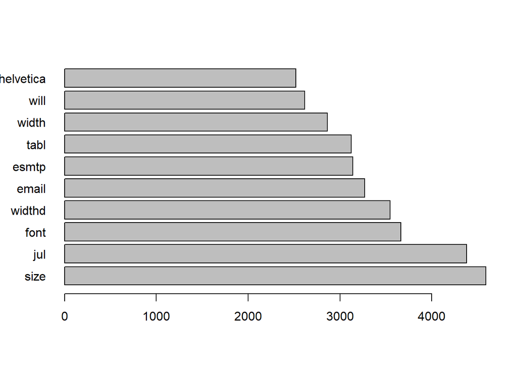

```r
spam_freq_ord <- spam_freq %>% order(decreasing = TRUE)
par(las=1)
barplot(spam_freq[spam_freq_ord[1:10]], horiz = TRUE)
```

```r
#For Ham
ham_freq <-  ham_dtm %>% as.matrix() %>% colSums()
length(ham_freq) #Should be the same as term count, not document count.
```

```
## [1] 3507
```

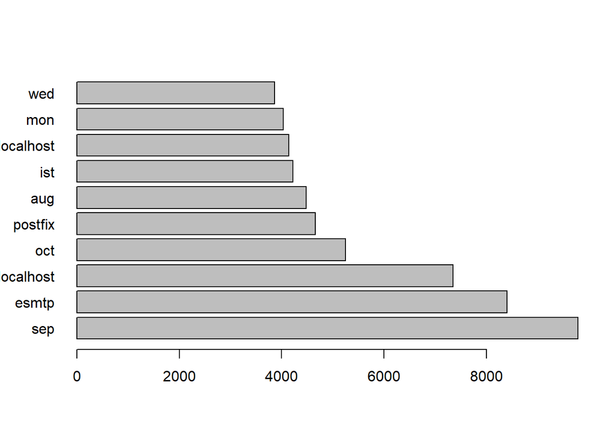

```r
ham_freq_ord <- ham_freq %>% order(decreasing = TRUE)
par(las=1)
barplot(ham_freq[ham_freq_ord[1:10]], horiz = TRUE)
```

## Document Analysis - Create container and use sets to findout accuracy

```r
# Used below code from R text book
lbls <- as.vector(unlist(meta(ham_spam, type="local", tag = "classification")))
head(lbls)
```

```
## [1] "Ham"  "Ham"  "Spam" "Spam" "Ham"  "Ham"
```

```r
N <- length(lbls)
container <- create_container(ham_spam_dtm, labels = lbls, trainSize = 1:501,testSize = 502:N,virgin = TRUE)
```

## Model - Support Vector Machine

> Use Support Vector Machine to supervise learning model to classify emails in the test set as ham or spam.

```r
svm_model <- train_model(container, "SVM")
svm_result <- classify_model(container,svm_model)
head(svm_result)
```

```
##   SVM_LABEL  SVM_PROB
## 1       Ham 0.9543802
## 2       Ham 0.9869500
## 3       Ham 0.9997587
## 4       Ham 0.9854293
## 5       Ham 0.9879737
## 6      Spam 0.9984496
```

```r
prop.table(table(svm_result[,1] == lbls[502:N]))
```

```
##
##      FALSE       TRUE
## 0.01118634 0.98881366
```

> This gave 98% accuracy

```r
tree_model <- train_model(container, "TREE")
tree_result <- classify_model(container, tree_model)
head(tree_result)
```

```
##   TREE_LABEL TREE_PROB
## 1       Spam     0.625
## 2        Ham     1.000
## 3        Ham     1.000
## 4        Ham     1.000
## 5        Ham     1.000
## 6       Spam     1.000
```

```r
prop.table(table(tree_result[,1] == lbls[502:N]))
```

```
##
##      FALSE       TRUE
## 0.02090079 0.97909921
```

> This gave 97% accuracy